# SeqMonk Vistory Report

## post-mapping QC H3K27me3

## Project Summary

### Basic Project Info

| Parameter | Value |
| --- | --- |
| Project Name | pluripotency_exit_TET_K27ac_K27m_K4m_input.smk |
| Vistory Name | [Not saved yet] |
| Genome | Mus musculus GRCm38_v95 |
| SeqMonk Version | 1.45.4 |

### Data Sets

| Name | File Name | Reads | Import Options |
| --- | --- | --- | --- |
| TET_KO_2i_H3K27me3_rep1_sensible_regions | Reimported from TET_KO_2i_H3K27me3_rep1 | 51412598 | Visible stores parser Filter by feature Excluding excluded_regions Remove DuplicatesNo |
| TET_KO_2i_H3K27me3_rep2_sensible_regions | Reimported from TET_KO_2i_H3K27me3_rep2 | 28509635 | Visible stores parser Filter by feature Excluding excluded_regions Remove DuplicatesNo |
| TET_KO_2i_H3K27me3_rep3_sensible_regions | Reimported from TET_KO_2i_H3K27me3_rep3 | 63857991 | Visible stores parser Filter by feature Excluding excluded_regions Remove DuplicatesNo |
| TET_KO_2i_H3K4me3_rep1_sensible_regions | Reimported from TET_KO_2i_H3K4me3_rep1 | 25899278 | Visible stores parser Filter by feature Excluding excluded_regions Remove DuplicatesNo |
| TET_KO_2i_H3K4me3_rep2_sensible_regions | Reimported from TET_KO_2i_H3K4me3_rep2 | 50192846 | Visible stores parser Filter by feature Excluding excluded_regions Remove DuplicatesNo |
| TET_KO_2i_H3K4me3_rep3_sensible_regions | Reimported from TET_KO_2i_H3K4me3_rep3 | 42621203 | Visible stores parser Filter by feature Excluding excluded_regions Remove DuplicatesNo |
| TET_KO_2i_HK27Ac_rep1_sensible_regions | Reimported from TET_KO_2i_HK27Ac_rep1 | 28877898 | Visible stores parser Filter by feature Excluding excluded_regions Remove DuplicatesNo |
| TET_KO_2i_HK27Ac_rep2_sensible_regions | Reimported from TET_KO_2i_HK27Ac_rep2 | 21884813 | Visible stores parser Filter by feature Excluding excluded_regions Remove DuplicatesNo |
| TET_KO_2i_HK27Ac_rep3_sensible_regions | Reimported from TET_KO_2i_HK27Ac_rep3 | 34244229 | Visible stores parser Filter by feature Excluding excluded_regions Remove DuplicatesNo |
| TET_KO_2i_Input_(from_K27Ac)_rep1_sensible_regions | Reimported from TET_KO_2i_Input_(from_K27Ac)_rep1 | 21568372 | Visible stores parser Filter by feature Excluding excluded_regions Remove DuplicatesNo |
| TET_KO_2i_Input_(from_K27Ac)_rep2_sensible_regions | Reimported from TET_KO_2i_Input_(from_K27Ac)_rep2 | 25999091 | Visible stores parser Filter by feature Excluding excluded_regions Remove DuplicatesNo |
| TET_KO_2i_Input_(from_K27Ac)_rep3_sensible_regions | Reimported from TET_KO_2i_Input_(from_K27Ac)_rep3 | 23911064 | Visible stores parser Filter by feature Excluding excluded_regions Remove DuplicatesNo |
| TET_KO_EpiLC_H3K27me3_rep1_sensible_regions | Reimported from TET_KO_EpiLC_H3K27me3_rep1 | 38162046 | Visible stores parser Filter by feature Excluding excluded_regions Remove DuplicatesNo |
| TET_KO_EpiLC_H3K27me3_rep2_sensible_regions | Reimported from TET_KO_EpiLC_H3K27me3_rep2 | 44042830 | Visible stores parser Filter by feature Excluding excluded_regions Remove DuplicatesNo |
| TET_KO_EpiLC_H3K27me3_rep3_sensible_regions | Reimported from TET_KO_EpiLC_H3K27me3_rep3 | 38915560 | Visible stores parser Filter by feature Excluding excluded_regions Remove DuplicatesNo |
| TET_KO_EpiLC_H3K4me3_rep1_sensible_regions | Reimported from TET_KO_EpiLC_H3K4me3_rep1 | 67260573 | Visible stores parser Filter by feature Excluding excluded_regions Remove DuplicatesNo |
| TET_KO_EpiLC_H3K4me3_rep2_sensible_regions | Reimported from TET_KO_EpiLC_H3K4me3_rep2 | 55942641 | Visible stores parser Filter by feature Excluding excluded_regions Remove DuplicatesNo |
| TET_KO_EpiLC_H3K4me3_rep3_sensible_regions | Reimported from TET_KO_EpiLC_H3K4me3_rep3 | 49719423 | Visible stores parser Filter by feature Excluding excluded_regions Remove DuplicatesNo |
| TET_KO_EpiLC_HK27Ac_rep1_sensible_regions | Reimported from TET_KO_EpiLC_HK27Ac_rep1 | 22760982 | Visible stores parser Filter by feature Excluding excluded_regions Remove DuplicatesNo |
| TET_KO_EpiLC_HK27Ac_rep2_sensible_regions | Reimported from TET_KO_EpiLC_HK27Ac_rep2 | 40802061 | Visible stores parser Filter by feature Excluding excluded_regions Remove DuplicatesNo |
| TET_KO_EpiLC_HK27Ac_rep3_sensible_regions | Reimported from TET_KO_EpiLC_HK27Ac_rep3 | 43247530 | Visible stores parser Filter by feature Excluding excluded_regions Remove DuplicatesNo |
| TET_KO_EpiLC_Input_(from_K27Ac)_rep1_sensible_regions | Reimported from TET_KO_EpiLC_Input_(from_K27Ac)_rep1 | 28899190 | Visible stores parser Filter by feature Excluding excluded_regions Remove DuplicatesNo |
| TET_KO_EpiLC_Input_(from_K27Ac)_rep2_sensible_regions | Reimported from TET_KO_EpiLC_Input_(from_K27Ac)_rep2 | 30319122 | Visible stores parser Filter by feature Excluding excluded_regions Remove DuplicatesNo |
| TET_KO_EpiLC_Input_(from_K27Ac)_rep3_sensible_regions | Reimported from TET_KO_EpiLC_Input_(from_K27Ac)_rep3 | 27791486 | Visible stores parser Filter by feature Excluding excluded_regions Remove DuplicatesNo |
| TET_WT_2i_H3K27me3_rep1_sensible_regions | Reimported from TET_WT_2i_H3K27me3_rep1 | 31542293 | Visible stores parser Filter by feature Excluding excluded_regions Remove DuplicatesNo |
| TET_WT_2i_H3K27me3_rep2_sensible_regions | Reimported from TET_WT_2i_H3K27me3_rep2 | 33319253 | Visible stores parser Filter by feature Excluding excluded_regions Remove DuplicatesNo |
| TET_WT_2i_H3K27me3_rep3_sensible_regions | Reimported from TET_WT_2i_H3K27me3_rep3 | 36228135 | Visible stores parser Filter by feature Excluding excluded_regions Remove DuplicatesNo |
| TET_WT_2i_H3K4me3_rep1_sensible_regions | Reimported from TET_WT_2i_H3K4me3_rep1 | 42525818 | Visible stores parser Filter by feature Excluding excluded_regions Remove DuplicatesNo |
| TET_WT_2i_H3K4me3_rep2_sensible_regions | Reimported from TET_WT_2i_H3K4me3_rep2 | 62977267 | Visible stores parser Filter by feature Excluding excluded_regions Remove DuplicatesNo |
| TET_WT_2i_H3K4me3_rep3_sensible_regions | Reimported from TET_WT_2i_H3K4me3_rep3 | 49514618 | Visible stores parser Filter by feature Excluding excluded_regions Remove DuplicatesNo |
| TET_WT_2i_HK27Ac_rep1_sensible_regions | Reimported from TET_WT_2i_HK27Ac_rep1 | 50362930 | Visible stores parser Filter by feature Excluding excluded_regions Remove DuplicatesNo |
| TET_WT_2i_HK27Ac_rep2_sensible_regions | Reimported from TET_WT_2i_HK27Ac_rep2 | 78499168 | Visible stores parser Filter by feature Excluding excluded_regions Remove DuplicatesNo |
| TET_WT_2i_HK27Ac_rep3_sensible_regions | Reimported from TET_WT_2i_HK27Ac_rep3 | 33992477 | Visible stores parser Filter by feature Excluding excluded_regions Remove DuplicatesNo |
| TET_WT_2i_Input_(from_K27Ac)_rep1_sensible_regions | Reimported from TET_WT_2i_Input_(from_K27Ac)_rep1 | 36015833 | Visible stores parser Filter by feature Excluding excluded_regions Remove DuplicatesNo |
| TET_WT_2i_Input_(from_K27Ac)_rep2_sensible_regions | Reimported from TET_WT_2i_Input_(from_K27Ac)_rep2 | 32510519 | Visible stores parser Filter by feature Excluding excluded_regions Remove DuplicatesNo |
| TET_WT_2i_Input_(from_K27Ac)_rep3_sensible_regions | Reimported from TET_WT_2i_Input_(from_K27Ac)_rep3 | 33866882 | Visible stores parser Filter by feature Excluding excluded_regions Remove DuplicatesNo |
| TET_WT_EpiLC_H3K27me3_rep1_sensible_regions | Reimported from TET_WT_EpiLC_H3K27me3_rep1 | 30086789 | Visible stores parser Filter by feature Excluding excluded_regions Remove DuplicatesNo |
| TET_WT_EpiLC_H3K27me3_rep2_sensible_regions | Reimported from TET_WT_EpiLC_H3K27me3_rep2 | 36051520 | Visible stores parser Filter by feature Excluding excluded_regions Remove DuplicatesNo |
| TET_WT_EpiLC_H3K27me3_rep3_sensible_regions | Reimported from TET_WT_EpiLC_H3K27me3_rep3 | 27897835 | Visible stores parser Filter by feature Excluding excluded_regions Remove DuplicatesNo |
| TET_WT_EpiLC_H3K4me3_rep1_sensible_regions | Reimported from TET_WT_EpiLC_H3K4me3_rep1 | 45962671 | Visible stores parser Filter by feature Excluding excluded_regions Remove DuplicatesNo |
| TET_WT_EpiLC_H3K4me3_rep2_sensible_regions | Reimported from TET_WT_EpiLC_H3K4me3_rep2 | 36222011 | Visible stores parser Filter by feature Excluding excluded_regions Remove DuplicatesNo |
| TET_WT_EpiLC_H3K4me3_rep3_sensible_regions | Reimported from TET_WT_EpiLC_H3K4me3_rep3 | 30462670 | Visible stores parser Filter by feature Excluding excluded_regions Remove DuplicatesNo |
| TET_WT_EpiLC_HK27Ac_rep1_sensible_regions | Reimported from TET_WT_EpiLC_HK27Ac_rep1 | 36423629 | Visible stores parser Filter by feature Excluding excluded_regions Remove DuplicatesNo |
| TET_WT_EpiLC_HK27Ac_rep2_sensible_regions | Reimported from TET_WT_EpiLC_HK27Ac_rep2 | 31559786 | Visible stores parser Filter by feature Excluding excluded_regions Remove DuplicatesNo |
| TET_WT_EpiLC_HK27Ac_rep3_sensible_regions | Reimported from TET_WT_EpiLC_HK27Ac_rep3 | 34532777 | Visible stores parser Filter by feature Excluding excluded_regions Remove DuplicatesNo |
| TET_WT_EpiLC_Input_(from_K27Ac)_rep1_sensible_regions | Reimported from TET_WT_EpiLC_Input_(from_K27Ac)_rep1 | 35254403 | Visible stores parser Filter by feature Excluding excluded_regions Remove DuplicatesNo |
| TET_WT_EpiLC_Input_(from_K27Ac)_rep2_sensible_regions | Reimported from TET_WT_EpiLC_Input_(from_K27Ac)_rep2 | 29614442 | Visible stores parser Filter by feature Excluding excluded_regions Remove DuplicatesNo |
| TET_WT_EpiLC_Input_(from_K27Ac)_rep3_sensible_regions | Reimported from TET_WT_EpiLC_Input_(from_K27Ac)_rep3 | 28771785 | Visible stores parser Filter by feature Excluding excluded_regions Remove DuplicatesNo |

### Replicate Sets

| TET_KO_2i_H3K27me3 | TET_KO_2i_H3K4me3 | TET_KO_2i_HK27Ac | TET_KO_2i_Input_(from_K27Ac) | TET_KO_EpiLC_H3K27me3 | TET_KO_EpiLC_H3K4me3 | TET_KO_EpiLC_HK27Ac | TET_KO_EpiLC_Input_(from_K27Ac) | TET_WT_2i_H3K27me3 | TET_WT_2i_H3K4me3 | TET_WT_2i_HK27Ac | TET_WT_2i_Input_(from_K27Ac) | TET_WT_EpiLC_H3K27me3 | TET_WT_EpiLC_H3K4me3 | TET_WT_EpiLC_HK27Ac | TET_WT_EpiLC_Input_(from_K27Ac) |
| --- | --- | --- | --- | --- | --- | --- | --- | --- | --- | --- | --- | --- | --- | --- | --- |
| TET_KO_2i_H3K27me3_rep1_sensible_regions | TET_KO_2i_H3K4me3_rep1_sensible_regions | TET_KO_2i_HK27Ac_rep1_sensible_regions | TET_KO_2i_Input_(from_K27Ac)_rep1_sensible_regions | TET_KO_EpiLC_H3K27me3_rep1_sensible_regions | TET_KO_EpiLC_H3K4me3_rep1_sensible_regions | TET_KO_EpiLC_HK27Ac_rep1_sensible_regions | TET_KO_EpiLC_Input_(from_K27Ac)_rep1_sensible_regions | TET_WT_2i_H3K27me3_rep1_sensible_regions | TET_WT_2i_H3K4me3_rep1_sensible_regions | TET_WT_2i_HK27Ac_rep1_sensible_regions | TET_WT_2i_Input_(from_K27Ac)_rep1_sensible_regions | TET_WT_EpiLC_H3K27me3_rep1_sensible_regions | TET_WT_EpiLC_H3K4me3_rep1_sensible_regions | TET_WT_EpiLC_HK27Ac_rep1_sensible_regions | TET_WT_EpiLC_Input_(from_K27Ac)_rep1_sensible_regions |
| TET_KO_2i_H3K27me3_rep2_sensible_regions | TET_KO_2i_H3K4me3_rep2_sensible_regions | TET_KO_2i_HK27Ac_rep2_sensible_regions | TET_KO_2i_Input_(from_K27Ac)_rep2_sensible_regions | TET_KO_EpiLC_H3K27me3_rep2_sensible_regions | TET_KO_EpiLC_H3K4me3_rep2_sensible_regions | TET_KO_EpiLC_HK27Ac_rep2_sensible_regions | TET_KO_EpiLC_Input_(from_K27Ac)_rep2_sensible_regions | TET_WT_2i_H3K27me3_rep2_sensible_regions | TET_WT_2i_H3K4me3_rep2_sensible_regions | TET_WT_2i_HK27Ac_rep2_sensible_regions | TET_WT_2i_Input_(from_K27Ac)_rep2_sensible_regions | TET_WT_EpiLC_H3K27me3_rep2_sensible_regions | TET_WT_EpiLC_H3K4me3_rep2_sensible_regions | TET_WT_EpiLC_HK27Ac_rep2_sensible_regions | TET_WT_EpiLC_Input_(from_K27Ac)_rep2_sensible_regions |
| TET_KO_2i_H3K27me3_rep3_sensible_regions | TET_KO_2i_H3K4me3_rep3_sensible_regions | TET_KO_2i_HK27Ac_rep3_sensible_regions | TET_KO_2i_Input_(from_K27Ac)_rep3_sensible_regions | TET_KO_EpiLC_H3K27me3_rep3_sensible_regions | TET_KO_EpiLC_H3K4me3_rep3_sensible_regions | TET_KO_EpiLC_HK27Ac_rep3_sensible_regions | TET_KO_EpiLC_Input_(from_K27Ac)_rep3_sensible_regions | TET_WT_2i_H3K27me3_rep3_sensible_regions | TET_WT_2i_H3K4me3_rep3_sensible_regions | TET_WT_2i_HK27Ac_rep3_sensible_regions | TET_WT_2i_Input_(from_K27Ac)_rep3_sensible_regions | TET_WT_EpiLC_H3K27me3_rep3_sensible_regions | TET_WT_EpiLC_H3K4me3_rep3_sensible_regions | TET_WT_EpiLC_HK27Ac_rep3_sensible_regions | TET_WT_EpiLC_Input_(from_K27Ac)_rep3_sensible_regions |

### Quantitation

| Name | Parent | Probes | Description | Comments |
| --- | --- | --- | --- | --- |
| 1kb tiles |  | 2725549 | Running windows of size 1000 with step size 1000. Quantitated with Read Count Quantitation using All Reads correcting for total count per million reads log transformed |  |
| Value above 0 in at least 1 | 1kb tiles | 318030 | [Probe Values Filter] Filter on probes in 1kb tiles where at least 1 of TET_KO_2i_HK27Ac , TET_KO_EpiLC_HK27Ac , TET_WT_2i_HK27Ac , TET_WT_EpiLC_HK27Ac had a value above 0.0. Quantitation was Read Cou… |  |

### Cumulative Distributions

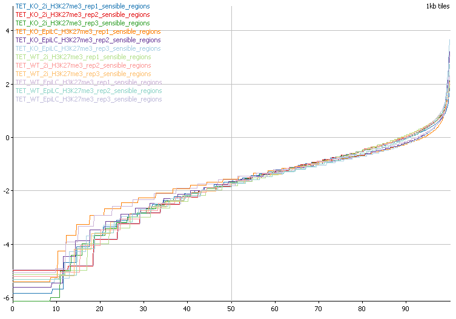

### PCA

New Probe List: Value above 0 in any (372469 probes)

[Probe Values Filter] Filter on probes in 1kb tiles where at least 1 of TET_KO_2i_H3K27me3 , TET_KO_EpiLC_H3K27me3 , TET_WT_2i_H3K27me3 , TET_WT_EpiLC_H3K27me3 had a value above 0.0. Quantitation was Read Count Quantitation using All Reads correcting for total count per million reads log transformed

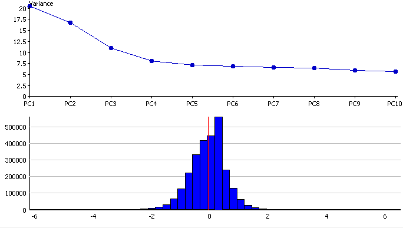

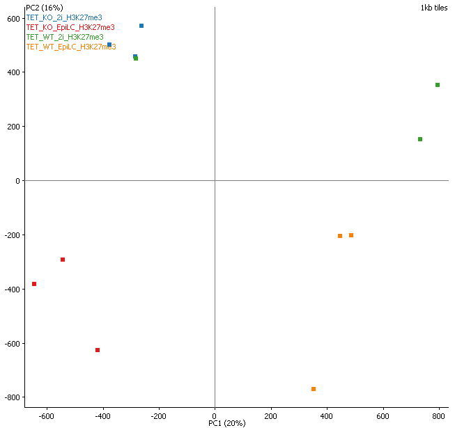

TET_WT_2i_H3K27me3_rep2 is the funky one.

Looking at cumulative distributions only for these three replicates.

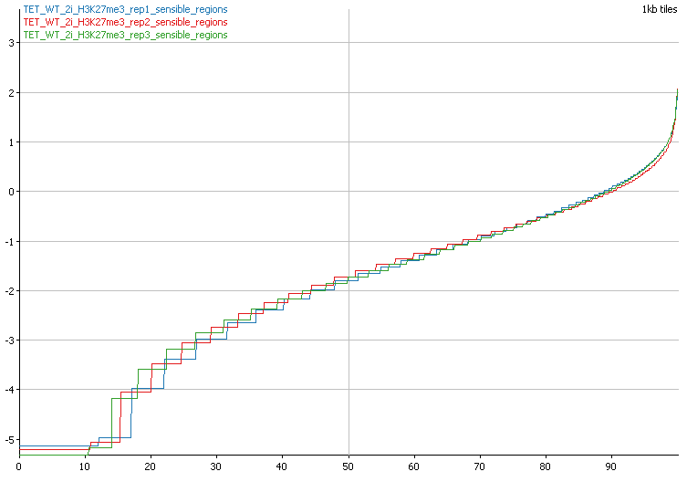

Hm, they look very similar.

| DataStore | Total Read Count | Forward Read Count | Reverse Read Count | Unknown Read Count | Mean Read Length | Total Read Length | Fold Coverage | Total Quantitation | Median Quantitation | Mean Quantitation | Valid Quantitations |
| --- | --- | --- | --- | --- | --- | --- | --- | --- | --- | --- | --- |
| TET_WT_2i_H3K27me3_rep1_sensible_regions | 31542293 | 15771131 | 15771162 | 0 | 195 | 6167605913 | 2.2628951282346046 | -5710051.130307021 | -1.8092905 | -2.0950096 | 2725549 |
| TET_WT_2i_H3K27me3_rep2_sensible_regions | 33319253 | 16655654 | 16663599 | 0 | 186 | 6229523450 | 2.285612677767764 | -5606899.79127475 | -1.7363561 | -2.0571635 | 2725549 |
| TET_WT_2i_H3K27me3_rep3_sensible_regions | 36228135 | 18114899 | 18113236 | 0 | 196 | 7101197237 | 2.6054298635342032 | -5632550.780120168 | -1.719607 | -2.0665748 | 2725549 |

Also similar read numbers

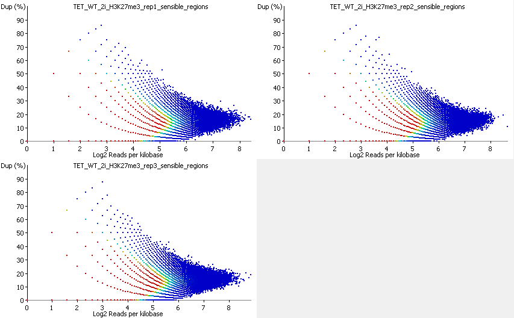

No issues with duplication ....

1) Scatter is much more similar to the KO than to the other WT

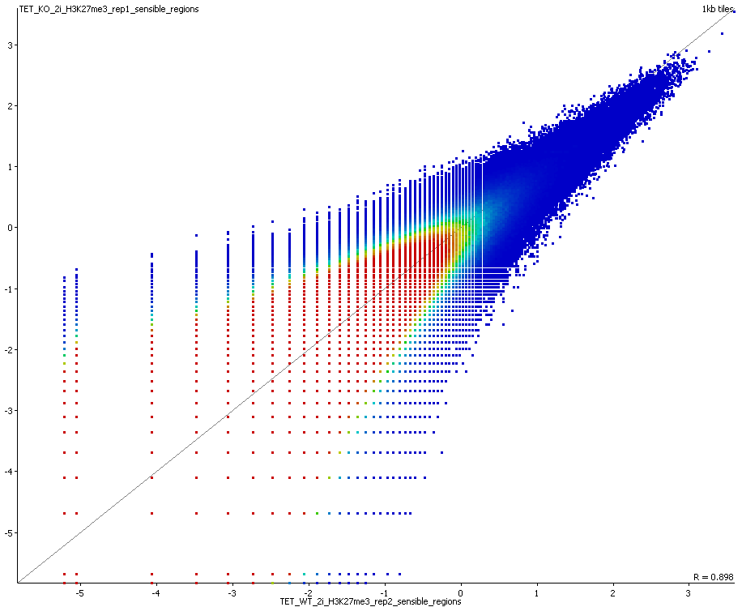

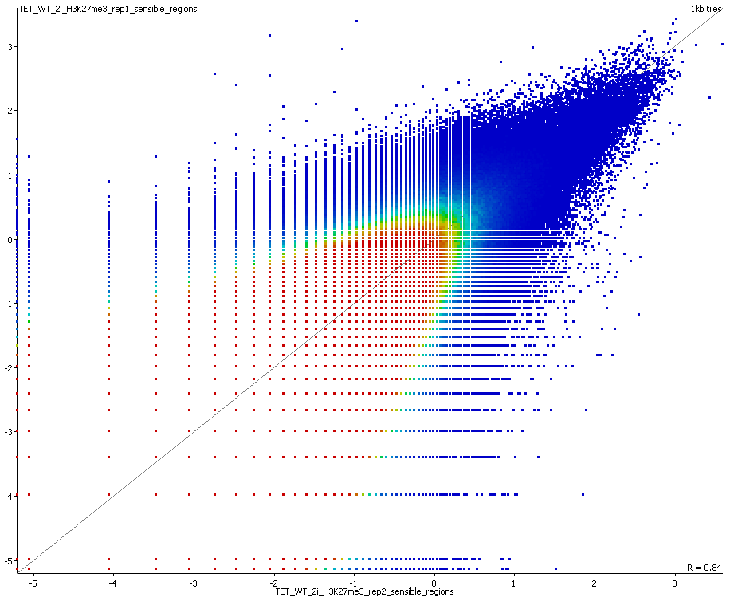

2) Some of the genetic differences between WT and KO seem to be matching up with KO rather than WT

3) But most informatively, you can actually see the deletion of the exons in TET3. Tet1 and Tet2 don't have very many reads for K27me3 so while the 'hole' is there, it's a bit icky, but for Tet3 it's rather obvious.

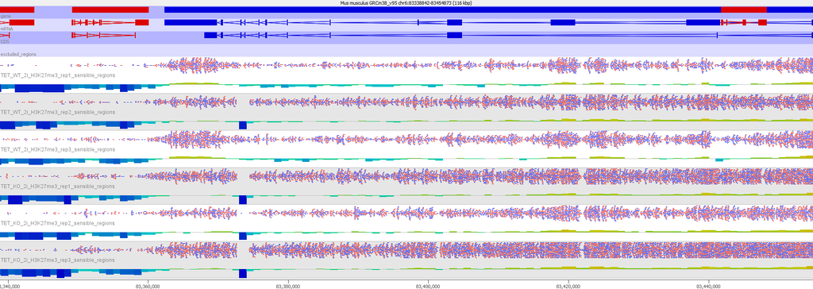

I also checked all of the other samples and they are all the genotype they claim.